# tisdale-data-checks

Inigo Peng, edited by Badhia Yunes-Katz

2025-07-09

# Database Tables

## tisdale

### catch

**- Findings catch:**

- date range is the same
- potential outlier value on folk_length (consistent in both DB and EDI)
- life stage in edi data has not gone through wrangling

#### Date Range Check

*EDI `date`*

```r
range(catch_tisdale_edi$date)
```

```
## [1] "2010-07-06" "2024-09-04"
```

*DB `date`*

```
## [1] "2010-07-06" "2024-09-04"
```

#### ForkLength

*EDI `forkLength`*

- 12.2 % of values in the `forkLength` column are NA.

```
##    Min. 1st Qu.  Median    Mean 3rd Qu.    Max.    NA's
##    0.00   38.00   42.00   54.73   75.00 4038.00    6984
```

*DB `fork_length`*

- 12.2 % of values in the `fork_length` column are NA.

```
##    Min. 1st Qu.  Median    Mean 3rd Qu.    Max.    NA's
##    0.00   38.00   42.00   54.73   75.00 4038.00    6983
```

*Forklength Exploration Plots*

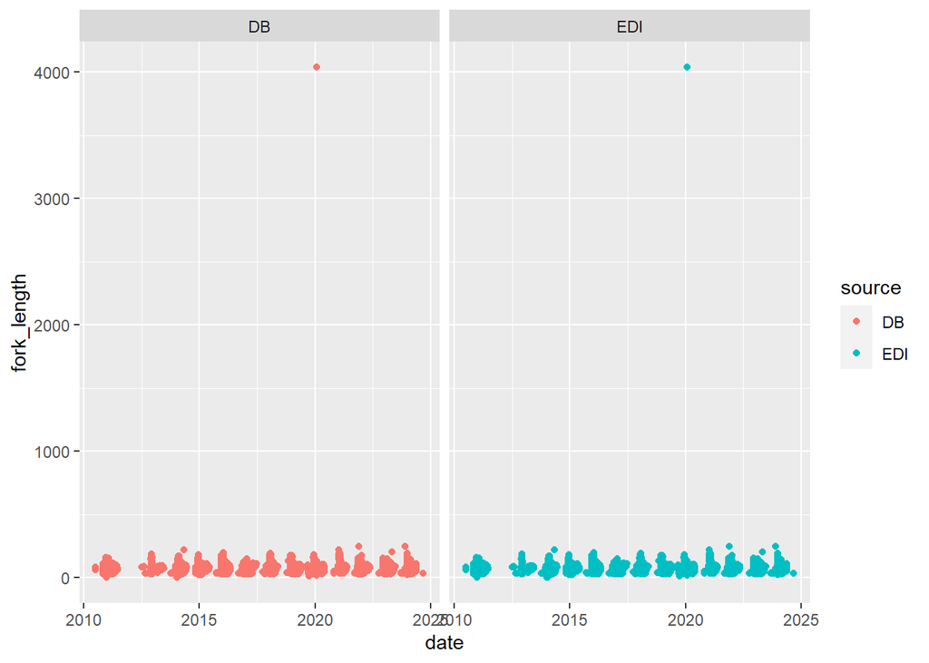

#### Lifestage

*EDI `lifeStage`*

- 0 % of values in the `lifeStage` column from the EDI data are NA.

*DB `lifestage_id`*

- 0 % of values in the `lifestage_id` column from the database are NA.

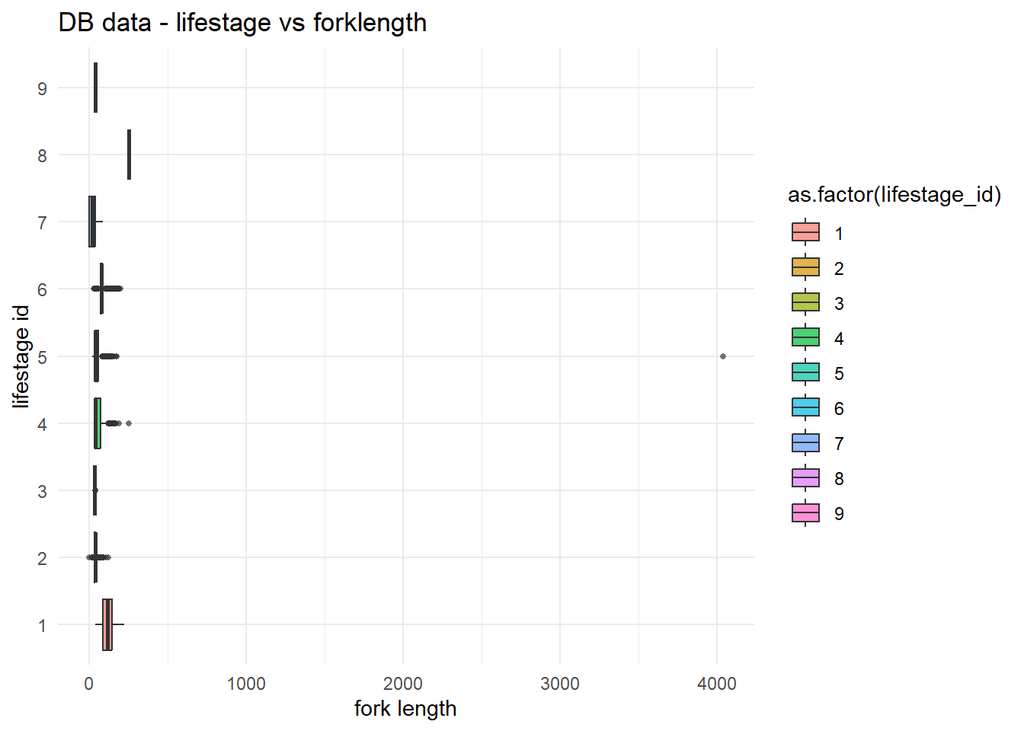

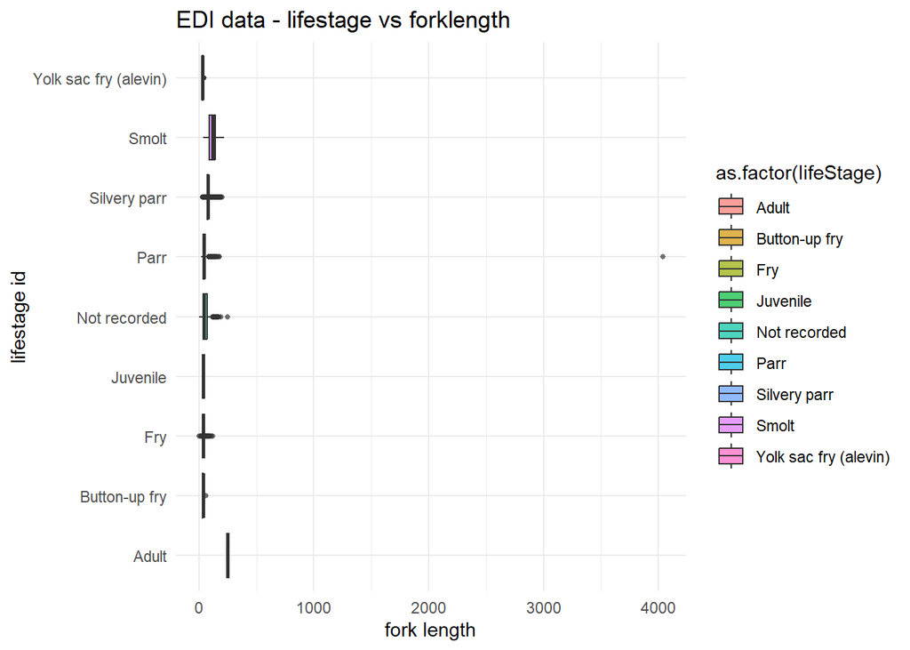

#### Count

*EDI `n`*

- 0 % of values in the `n` column in edi data are NA.

```
##    Min. 1st Qu.  Median    Mean 3rd Qu.    Max.
##    0.00    1.00    1.00    2.13    1.00 4602.00
```

*DB `count`*

- 0 % of values in the `count` column in database data are NA.

```
##    Min. 1st Qu.  Median    Mean 3rd Qu.    Max.
##    0.00    1.00    1.00    2.13    1.00 4602.00
```

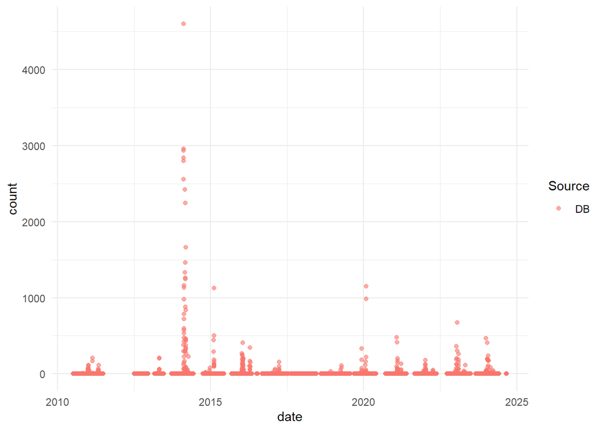

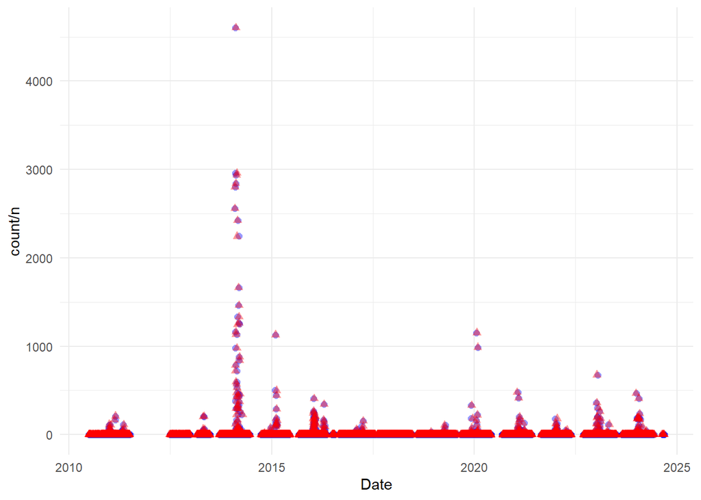

Random pick of data entry to compare between db and EDI

- test 1

```
## Rows: 1
## Columns: 17
## $ id               <int> 67224430
## $ catch_raw_id     <chr> "400"
## $ trap_location_id <int> 56
## $ date             <date> 2014-12-22
## $ count            <dbl> 1
## $ run_id           <int> 2
## $ lifestage_id     <int> 2
## $ adipose_clipped  <lgl> FALSE
## $ dead             <lgl> NA
## $ fork_length      <dbl> 39
## $ weight           <dbl> NA
## $ actual_count     <lgl> NA
## $ updated_at       <dttm> 2025-07-08 23:05:48
## $ stream           <chr> "sacramento river"
## $ site             <chr> "tisdale"
## $ subsite          <chr> "rl"
## $ source           <chr> "DB"
```

```
## Rows: 1
## Columns: 23
## $ ProjectDescriptionID <dbl> 10
## $ catchRawID           <dbl> 400
## $ trapVisitID          <dbl> 91
## $ commonName           <chr> "Chinook salmon"
## $ releaseID            <dbl> 0
## $ atCaptureRun         <chr> "Spring"
## $ fishOrigin           <chr> "Natural"
## $ lifeStage            <chr> "Fry"
## $ forkLength           <dbl> 39
## $ totalLength          <dbl> NA
## $ n                    <dbl> 1
## $ visitTime            <dttm> 2014-12-22 15:30:34
## $ visitTime2           <dttm> 2014-12-22 15:30:34
## $ visitType            <chr> "Continue trapping"
## $ siteName             <chr> "tisdale"
## $ subSiteName          <chr> "rl"
## $ finalRun             <chr> "Spring"
## $ actualCount          <chr> "Yes"
## $ trap_start_date      <dttm> 2014-12-22 15:30:34
## $ trap_end_date        <dttm> 2014-12-22 15:30:34
## $ stream               <chr> "sacramento river"
## $ date                 <date> 2014-12-22
## $ source               <chr> "EDI"
```

- test 2

```
## Rows: 1
## Columns: 17
## $ id               <int> 67220529
## $ catch_raw_id     <chr> "18663"
## $ trap_location_id <int> 56
## $ date             <date> 2014-02-17
## $ count            <dbl> 1
## $ run_id           <int> 3
## $ lifestage_id     <int> 5
## $ adipose_clipped  <lgl> FALSE
## $ dead             <lgl> NA
## $ fork_length      <dbl> 39
## $ weight           <dbl> NA
## $ actual_count     <lgl> NA
## $ updated_at       <dttm> 2025-07-08 23:05:48
## $ stream           <chr> "sacramento river"
## $ site             <chr> "tisdale"
## $ subsite          <chr> "rl"
## $ source           <chr> "DB"
```

```
## Rows: 1
## Columns: 23
## $ ProjectDescriptionID <dbl> 10
## $ catchRawID           <dbl> 18663
## $ trapVisitID          <dbl> 1761
## $ commonName           <chr> "Chinook salmon"
## $ releaseID            <dbl> 0
## $ atCaptureRun         <chr> "Fall"
## $ fishOrigin           <chr> "Natural"
## $ lifeStage            <chr> "Parr"
## $ forkLength           <dbl> 39
## $ totalLength          <dbl> NA
## $ n                    <dbl> 1
## $ visitTime            <dttm> 2014-02-17 15:45:34
## $ visitTime2           <dttm> 2014-02-17 15:45:34
## $ visitType            <chr> "Continue trapping"
## $ siteName             <chr> "tisdale"
## $ subSiteName          <chr> "rl"
## $ finalRun             <chr> "Fall"
## $ actualCount          <chr> "Yes"
## $ trap_start_date      <dttm> 2014-02-17 15:45:34
## $ trap_end_date        <dttm> 2014-02-17 15:45:34
## $ stream               <chr> "sacramento river"
## $ date                 <date> 2014-02-17
## $ source               <chr> "EDI"
```

- test 3

```
## Rows: 1
## Columns: 17
## $ id               <int> 67249210
## $ catch_raw_id     <chr> "1600"
## $ trap_location_id <int> 55
## $ date             <date> 2014-10-31
## $ count            <dbl> 14
## $ run_id           <int> 4
## $ lifestage_id     <int> 4
## $ adipose_clipped  <lgl> FALSE
## $ dead             <lgl> NA
## $ fork_length      <dbl> NA
## $ weight           <dbl> NA
## $ actual_count     <lgl> NA
## $ updated_at       <dttm> 2025-07-08 23:05:48
## $ stream           <chr> "sacramento river"
## $ site             <chr> "tisdale"
## $ subsite          <chr> "rr"
## $ source           <chr> "DB"
```

```
## Rows: 1
## Columns: 23
## $ ProjectDescriptionID <dbl> 10
## $ catchRawID           <dbl> 1600
## $ trapVisitID          <dbl> 235
## $ commonName           <chr> "Chinook salmon"
## $ releaseID            <dbl> 0
## $ atCaptureRun         <chr> "Winter"
## $ fishOrigin           <chr> "Natural"
## $ lifeStage            <chr> "Not recorded"
## $ forkLength           <dbl> NA
## $ totalLength          <dbl> NA
## $ n                    <dbl> 14
## $ visitTime            <dttm> 2014-10-31 10:00:34
## $ visitTime2           <dttm> 2014-10-31 10:00:34
## $ visitType            <chr> "Unplanned restart"
## $ siteName             <chr> "tisdale"
## $ subSiteName          <chr> "rr"
## $ finalRun             <chr> "Winter"
## $ actualCount          <chr> "Yes"
## $ trap_start_date      <dttm> 2014-10-31 10:00:34
## $ trap_end_date        <dttm> 2014-10-31 10:00:34
## $ stream               <chr> "sacramento river"
## $ date                 <date> 2014-10-31
## $ source               <chr> "EDI"
```

### trap

**- Findings:**

#### Date Range Check

*DB `trap_visit_time_start`*

```
## [1] "2010-07-06 13:00:34 UTC" "2024-10-09 10:00:56 UTC"
```

*EDI `visitTime`*

```r
range(trap_tisdale_edi$visitTime)
```

```
## [1] "2010-07-06 13:00:34 UTC" "2024-10-09 10:00:56 UTC"
```

#### water_velocity

*DB `water_velocity`*

- 19 % of values in the `water_velocity` column are NA.

```
##    Min. 1st Qu.  Median    Mean 3rd Qu.    Max.    NA's
##   0.000   0.500   1.200   1.257   1.900  63.000    1423
```

*EDI `waterVel`* * 19 % of values in the `water_velocity` column are NA.

```
##    Min. 1st Qu.  Median    Mean 3rd Qu.    Max.    NA's
##   0.000   0.500   1.200   1.257   1.900  63.000    1424
```

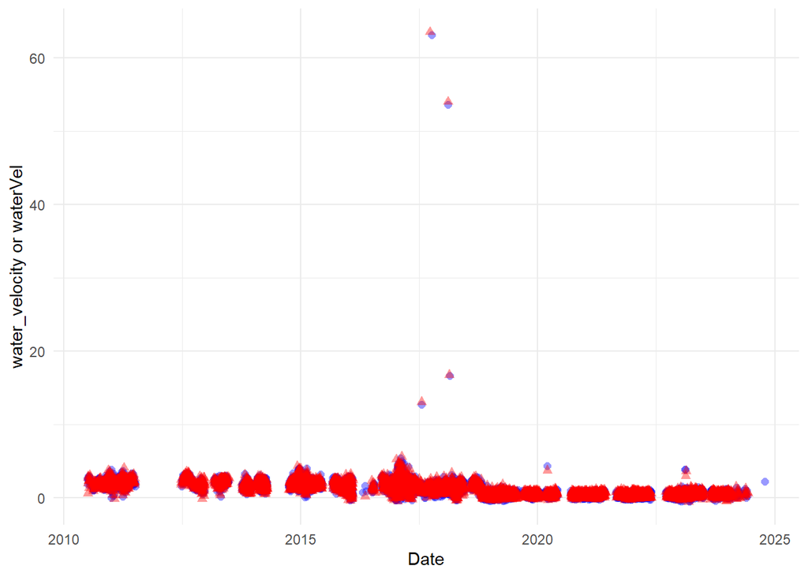

#### fishProcessed

*DB `fish_processed_id`*

- 2.9 % of values in the `fish_processed_id` column are NA.

```
##
##    2    3    4    5
## 4706 2553   10    4
```

*EDI `fishProcessed`* * 0 % of values in the `fishProcessed` column are NA.

```
##
##            N/A; not a sampling visit No catch data; fish left in live box
##                                  214                                    4
##         No catch data; fish released                  No fish were caught
##                                   10                                 2553
##                       Processed fish
##                                 4706
```

Random pick of data entry by date to compare between db and EDI

- test 1

```
## Rows: 1
## Columns: 25
## $ id                         <int> 3094778
## $ trap_location_id           <int> 56
## $ trap_visit_id              <chr> "380"
## $ visit_type_id              <int> 2
## $ trap_visit_time_start      <date> 2015-09-27
## $ trap_visit_time_end        <dttm> 2015-09-28 08:00:34
## $ trap_functioning_id        <int> NA
## $ in_half_cone_configuration <lgl> NA
## $ fish_processed_id          <int> 2
## $ rpm_start                  <dbl> 2.3
## $ rpm_end                    <dbl> 2.3
## $ total_revolutions          <dbl> 3482
## $ debris_volume              <dbl> NA
## $ debris_level_id            <int> NA
## $ discharge                  <dbl> NA
## $ water_velocity             <dbl> 1.9
## $ water_temp                 <dbl> 17.77778
## $ turbidity                  <dbl> 9.53
## $ include                    <lgl> NA
## $ updated_at                 <dttm> 2025-07-08 23:06:39
## $ updated_by                 <chr> "AdminJPE"
## $ stream                     <chr> "sacramento river"
## $ site                       <chr> "tisdale"
## $ subsite                    <chr> "rl"
## $ source                     <chr> "DB"
```

```
## Rows: 1
## Columns: 26
## $ projectDescriptionID  <dbl> 10
## $ trapVisitID           <dbl> 380
## $ siteName              <chr> "tisdale"
## $ subSiteName           <chr> "rl"
## $ visitTime             <date> 2015-09-28
## $ visitTime2            <dttm> 2015-09-28 08:00:34
## $ visitType             <chr> "Continue trapping"
## $ fishProcessed         <chr> "Processed fish"
## $ trapFunctioning       <chr> "Trap functioning normally"
## $ counterAtStart        <dbl> NA
## $ counterAtEnd          <dbl> 3482
## $ rpmRevolutionsAtStart <dbl> 2.3
## $ rpmRevolutionsAtEnd   <dbl> 2.3
## $ includeCatch          <chr> "Yes"
## $ discharge             <dbl> NA
## $ waterVel              <dbl> 1.9
## $ waterTemp             <dbl> 17.77778
## $ lightPenetration      <dbl> 5.95
## $ turbidity             <dbl> 9.53
## $ dissolvedOxygen       <dbl> NA
## $ conductivity          <dbl> NA
## $ trap_start_date       <dttm> 2015-09-27 08:00:34
## $ trap_end_date         <dttm> 2015-09-28 08:00:34
## $ stream                <chr> "sacramento river"
## $ date                  <date> 2015-09-28
## $ source                <chr> "EDI"
```

- test 2

```
## Rows: 1
## Columns: 25
## $ id                         <int> 3093609
## $ trap_location_id           <int> 56
## $ trap_visit_id              <chr> "2037"
## $ visit_type_id              <int> 2
## $ trap_visit_time_start      <date> 2010-07-22
## $ trap_visit_time_end        <dttm> 2010-07-28 11:15:34
## $ trap_functioning_id        <int> NA
## $ in_half_cone_configuration <lgl> NA
## $ fish_processed_id          <int> 3
## $ rpm_start                  <dbl> 2.8
## $ rpm_end                    <dbl> 2.8
## $ total_revolutions          <dbl> 21511
## $ debris_volume              <dbl> NA
## $ debris_level_id            <int> NA
## $ discharge                  <dbl> NA
## $ water_velocity             <dbl> 2.52
## $ water_temp                 <dbl> 19.44444
## $ turbidity                  <dbl> 2.42
## $ include                    <lgl> NA
## $ updated_at                 <dttm> 2025-07-08 23:06:39
## $ updated_by                 <chr> "AdminJPE"
## $ stream                     <chr> "sacramento river"
## $ site                       <chr> "tisdale"
## $ subsite                    <chr> "rl"
## $ source                     <chr> "DB"
```

```
## Rows: 1
## Columns: 26
## $ projectDescriptionID  <dbl> 10
## $ trapVisitID           <dbl> 2037
## $ siteName              <chr> "tisdale"
## $ subSiteName           <chr> "rl"
## $ visitTime             <date> 2010-07-28
## $ visitTime2            <dttm> 2010-07-28 11:15:34
## $ visitType             <chr> "Continue trapping"
## $ fishProcessed         <chr> "No fish were caught"
## $ trapFunctioning       <chr> "Trap functioning normally"
## $ counterAtStart        <dbl> NA
## $ counterAtEnd          <dbl> 21511
## $ rpmRevolutionsAtStart <dbl> 2.8
## $ rpmRevolutionsAtEnd   <dbl> 2.8
## $ includeCatch          <chr> "Yes"
## $ discharge             <dbl> NA
## $ waterVel              <dbl> 2.52
## $ waterTemp             <dbl> 19.44444
## $ lightPenetration      <dbl> 5
## $ turbidity             <dbl> 2.42
## $ dissolvedOxygen       <dbl> NA
## $ conductivity          <dbl> NA
## $ trap_start_date       <dttm> 2010-07-22 11:00:34
## $ trap_end_date         <dttm> 2010-07-28 11:15:34
## $ stream                <chr> "sacramento river"
## $ date                  <date> 2010-07-28
## $ source                <chr> "EDI"
```

- test 3

```
## Rows: 1
## Columns: 25
## $ id                         <int> 3098765
## $ trap_location_id           <int> 55
## $ trap_visit_id              <chr> "2015"
## $ visit_type_id              <int> 2
## $ trap_visit_time_start      <date> 2016-03-27
## $ trap_visit_time_end        <dttm> 2016-03-28 09:45:34
## $ trap_functioning_id        <int> NA
## $ in_half_cone_configuration <lgl> NA
## $ fish_processed_id          <int> 2
## $ rpm_start                  <dbl> 4.2
## $ rpm_end                    <dbl> 4.2
## $ total_revolutions          <dbl> 3599
## $ debris_volume              <dbl> NA
## $ debris_level_id            <int> NA
## $ discharge                  <dbl> NA
## $ water_velocity             <dbl> NA
## $ water_temp                 <dbl> 13.88889
## $ turbidity                  <dbl> 50.1
## $ include                    <lgl> NA
## $ updated_at                 <dttm> 2025-07-08 23:06:39
## $ updated_by                 <chr> "AdminJPE"
## $ stream                     <chr> "sacramento river"
## $ site                       <chr> "tisdale"
## $ subsite                    <chr> "rr"
## $ source                     <chr> "DB"
```

```
## Rows: 1
## Columns: 26
## $ projectDescriptionID  <dbl> 10
## $ trapVisitID           <dbl> 2015
## $ siteName              <chr> "tisdale"
## $ subSiteName           <chr> "rr"
## $ visitTime             <date> 2016-03-28
## $ visitTime2            <dttm> 2016-03-28 09:45:34
## $ visitType             <chr> "Continue trapping"
## $ fishProcessed         <chr> "Processed fish"
## $ trapFunctioning       <chr> "Trap functioning normally"
## $ counterAtStart        <dbl> NA
## $ counterAtEnd          <dbl> 3599
## $ rpmRevolutionsAtStart <dbl> 4.2
## $ rpmRevolutionsAtEnd   <dbl> 4.2
## $ includeCatch          <chr> "Yes"
## $ discharge             <dbl> NA
## $ waterVel              <dbl> NA
## $ waterTemp             <dbl> 13.88889
## $ lightPenetration      <dbl> 1.5
## $ turbidity             <dbl> 50.1
## $ dissolvedOxygen       <dbl> NA
## $ conductivity          <dbl> NA
## $ trap_start_date       <dttm> 2016-03-27 16:30:34
## $ trap_end_date         <dttm> 2016-03-28 09:45:34
## $ stream                <chr> "sacramento river"
## $ date                  <date> 2016-03-28
## $ source                <chr> "EDI"
```

- test 4

```
## Rows: 1
## Columns: 25
## $ id                         <int> 3100676
## $ trap_location_id           <int> 55
## $ trap_visit_id              <chr> "6919"
## $ visit_type_id              <int> 4
## $ trap_visit_time_start      <date> 2023-03-13
## $ trap_visit_time_end        <dttm> 2023-03-13 11:30:53
## $ trap_functioning_id        <int> NA
## $ in_half_cone_configuration <lgl> NA
## $ fish_processed_id          <int> 3
## $ rpm_start                  <dbl> 0
## $ rpm_end                    <dbl> 1.7
## $ total_revolutions          <dbl> NA
## $ debris_volume              <dbl> NA
## $ debris_level_id            <int> NA
## $ discharge                  <dbl> NA
## $ water_velocity             <dbl> NA
## $ water_temp                 <dbl> NA
## $ turbidity                  <dbl> NA
## $ include                    <lgl> NA
## $ updated_at                 <dttm> 2025-07-08 23:06:39
## $ updated_by                 <chr> "AdminJPE"
## $ stream                     <chr> "sacramento river"
## $ site                       <chr> "tisdale"
## $ subsite                    <chr> "rr"
## $ source                     <chr> "DB"
```

```
## Rows: 1
## Columns: 26
## $ projectDescriptionID  <dbl> 10
## $ trapVisitID           <dbl> 6919
## $ siteName              <chr> "tisdale"
## $ subSiteName           <chr> "rr"
## $ visitTime             <date> 2023-03-13
## $ visitTime2            <dttm> 2023-03-13 11:30:53
## $ visitType             <chr> "Start trap & begin trapping"
## $ fishProcessed         <chr> "No fish were caught"
## $ trapFunctioning       <chr> "Trap not in service"
## $ counterAtStart        <dbl> 0
## $ counterAtEnd          <dbl> NA
## $ rpmRevolutionsAtStart <dbl> 0
## $ rpmRevolutionsAtEnd   <dbl> 1.7
## $ includeCatch          <chr> "Yes"
## $ discharge             <dbl> NA
## $ waterVel              <dbl> NA
## $ waterTemp             <dbl> NA
## $ lightPenetration      <dbl> NA
## $ turbidity             <dbl> NA
## $ dissolvedOxygen       <dbl> NA
## $ conductivity          <dbl> NA
## $ trap_start_date       <dttm> 2023-03-13 11:30:53
## $ trap_end_date         <dttm> 2023-03-13 11:30:53
## $ stream                <chr> "sacramento river"
## $ date                  <date> 2023-03-13
## $ source                <chr> "EDI"
```

### release

**- Findings:**

- date range is the same

#### Date Range Check

*DB `date_released`*

```
## [1] "2012-02-05 12:00:32 UTC" "2024-03-28 12:00:08 UTC"
```

*EDI `releaseTime`*

```r
range(release_tisdale_edi$releaseTime)
```

```
## [1] "2012-02-05 12:00:32 UTC" "2024-03-28 12:00:08 UTC"
```

#### markedLifeStage

*EDI `markedLifeStage`*

- 96.8 % of values in the `markedLifeStage` column are NA.

```
##
## Not recorded
##            2
```

*DB `lifestage_id`*

- 0 % of values in the `fork_length` column are NA.

```
##    Min. 1st Qu.  Median    Mean 3rd Qu.    Max.
##   4.000   7.000   7.000   6.905   7.000   7.000
```

```
##
##  4  7
##  2 61
```

#### nReleased

*EDI `nReleased`*

- 0 % of values in the `nReleased` column are NA.

```
##    Min. 1st Qu.  Median    Mean 3rd Qu.    Max.
##    75.0   340.0   500.0   609.3   995.0  1941.0
```

*DB `number_released`*

- 0 % of values in the `number_released` column are NA.

```
##    Min. 1st Qu.  Median    Mean 3rd Qu.    Max.
##    75.0   340.0   500.0   609.3   995.0  1941.0
```

*Exploration Plots*

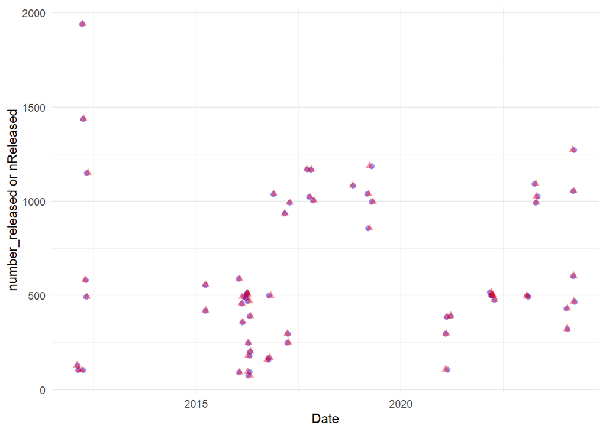

Random pick of data entry by date to compare between db and EDI

- test 1

```
## Rows: 1
## Columns: 15
## $ id                          <int> 117316
## $ trap_location_id            <int> 57
## $ release_id                  <chr> "297"
## $ date_released               <dttm> 2012-04-22 12:00:32
## $ run_id                      <int> 3
## $ median_fork_length_released <dbl> NA
## $ lifestage_id                <int> 7
## $ origin_id                   <int> 2
## $ number_released             <dbl> 494
## $ updated_at                  <dttm> 2025-07-08 23:06:38
## $ updated_by                  <chr> "AdminJPE"
## $ stream                      <chr> "sacramento river"
## $ site                        <chr> "tisdale"
## $ subsite                     <chr> NA
## $ source                      <chr> "DB"
```

```
## Rows: 1
## Columns: 20
## $ projectDescriptionID <dbl> 10
## $ releaseID            <dbl> 297
## $ commonName           <chr> "Chinook salmon"
## $ markedRun            <chr> "Fall"
## $ markedLifeStage      <chr> NA
## $ markedFishOrigin     <chr> "Hatchery"
## $ sourceOfFishSite     <chr> NA
## $ releaseSite          <chr> "tisdale"
## $ releaseSubSite       <chr> NA
## $ nReleased            <dbl> 494
## $ releaseTime          <dttm> 2012-04-22 12:00:32
## $ testDays             <dbl> 7
## $ appliedMarkType      <chr> "Pigment / dye"
## $ appliedMarkColor     <chr> "Not applicable (n/a)"
## $ appliedMarkPosition  <chr> "Not applicable (n/a)"
## $ appliedMarkCode      <lgl> NA
## $ includeAnalysis      <chr> "Yes"
## $ stream               <chr> "sacramento river"
## $ date                 <date> 2012-04-22
## $ source               <chr> "EDI"
```

- test 2

```
## Rows: 1
## Columns: 15
## $ id                          <int> 117316
## $ trap_location_id            <int> 57
## $ release_id                  <chr> "297"
## $ date_released               <dttm> 2012-04-22 12:00:32
## $ run_id                      <int> 3
## $ median_fork_length_released <dbl> NA
## $ lifestage_id                <int> 7
## $ origin_id                   <int> 2
## $ number_released             <dbl> 494
## $ updated_at                  <dttm> 2025-07-08 23:06:38
## $ updated_by                  <chr> "AdminJPE"
## $ stream                      <chr> "sacramento river"
## $ site                        <chr> "tisdale"
## $ subsite                     <chr> NA
## $ source                      <chr> "DB"
```

```
## Rows: 1
## Columns: 20
## $ projectDescriptionID <dbl> 10
## $ releaseID            <dbl> 297
## $ commonName           <chr> "Chinook salmon"
## $ markedRun            <chr> "Fall"
## $ markedLifeStage      <chr> NA
## $ markedFishOrigin     <chr> "Hatchery"
## $ sourceOfFishSite     <chr> NA
## $ releaseSite          <chr> "tisdale"
## $ releaseSubSite       <chr> NA
## $ nReleased            <dbl> 494
## $ releaseTime          <dttm> 2012-04-22 12:00:32
## $ testDays             <dbl> 7
## $ appliedMarkType      <chr> "Pigment / dye"
## $ appliedMarkColor     <chr> "Not applicable (n/a)"
## $ appliedMarkPosition  <chr> "Not applicable (n/a)"
## $ appliedMarkCode      <lgl> NA
## $ includeAnalysis      <chr> "Yes"
## $ stream               <chr> "sacramento river"
## $ date                 <date> 2012-04-22
## $ source               <chr> "EDI"
```

- test 3

```
## Rows: 1
## Columns: 15
## $ id                          <int> 117341
## $ trap_location_id            <int> 57
## $ release_id                  <chr> "322"
## $ date_released               <dttm> 2024-03-12 12:00:08
## $ run_id                      <int> 3
## $ median_fork_length_released <dbl> NA
## $ lifestage_id                <int> 7
## $ origin_id                   <int> 2
## $ number_released             <dbl> 1054
## $ updated_at                  <dttm> 2025-07-08 23:06:38
## $ updated_by                  <chr> "AdminJPE"
## $ stream                      <chr> "sacramento river"
## $ site                        <chr> "tisdale"
## $ subsite                     <chr> NA
## $ source                      <chr> "DB"
```

```
## Rows: 1
## Columns: 20
## $ projectDescriptionID <dbl> 10
## $ releaseID            <dbl> 322
## $ commonName           <chr> "Chinook salmon"
## $ markedRun            <chr> "Fall"
## $ markedLifeStage      <chr> NA
## $ markedFishOrigin     <chr> "Hatchery"
## $ sourceOfFishSite     <chr> NA
## $ releaseSite          <chr> "tisdale"
## $ releaseSubSite       <chr> NA
## $ nReleased            <dbl> 1054
## $ releaseTime          <dttm> 2024-03-12 12:00:08
## $ testDays             <dbl> 7
## $ appliedMarkType      <chr> "Pigment / dye"
## $ appliedMarkColor     <chr> "Brown"
## $ appliedMarkPosition  <chr> "Whole body"
## $ appliedMarkCode      <lgl> NA
## $ includeAnalysis      <chr> "Yes"
## $ stream               <chr> "sacramento river"
## $ date                 <date> 2024-03-12
## $ source               <chr> "EDI"
```

- test 4

```
## Rows: 1
## Columns: 15
## $ id                          <int> 117314
## $ trap_location_id            <int> 57
## $ release_id                  <chr> "295"
## $ date_released               <dttm> 2012-04-01 12:00:32
## $ run_id                      <int> 3
## $ median_fork_length_released <dbl> NA
## $ lifestage_id                <int> 7
## $ origin_id                   <int> 2
## $ number_released             <dbl> 1438
## $ updated_at                  <dttm> 2025-07-08 23:06:38
## $ updated_by                  <chr> "AdminJPE"
## $ stream                      <chr> "sacramento river"
## $ site                        <chr> "tisdale"
## $ subsite                     <chr> NA
## $ source                      <chr> "DB"
```

```
## Rows: 1
## Columns: 20
## $ projectDescriptionID <dbl> 10
## $ releaseID            <dbl> 295
## $ commonName           <chr> "Chinook salmon"
## $ markedRun            <chr> "Fall"
## $ markedLifeStage      <chr> NA
## $ markedFishOrigin     <chr> "Hatchery"
## $ sourceOfFishSite     <chr> NA
## $ releaseSite          <chr> "tisdale"
## $ releaseSubSite       <chr> NA
## $ nReleased            <dbl> 1438
## $ releaseTime          <dttm> 2012-04-01 12:00:32
## $ testDays             <dbl> 7
## $ appliedMarkType      <chr> "Pigment / dye"
## $ appliedMarkColor     <chr> "Not applicable (n/a)"
## $ appliedMarkPosition  <chr> "Not applicable (n/a)"
## $ appliedMarkCode      <lgl> NA
## $ includeAnalysis      <chr> "Yes"
## $ stream               <chr> "sacramento river"
## $ date                 <date> 2012-04-01
## $ source               <chr> "EDI"
```

### recapture

**- Findings:**

- date range is the same

#### Date Range Check

*DB `date`*

```
## [1] "2010-12-12" "2024-03-29"
```

*EDI `date`*

```r
range(recapture_tisdale_edi$date)
```

```
## [1] "2010-12-12" "2024-03-29"
```

#### Count

*DB `count`*

- 0 % of values in the `count` column are NA.

```
##    Min. 1st Qu.  Median    Mean 3rd Qu.    Max.
##   0.000   1.000   1.000   1.826   1.000  18.000
```

*EDI `n`*

- 0 % of values in the `n` column are NA.

```r
summary(recapture_tisdale_edi$n)
```

```
##    Min. 1st Qu.  Median    Mean 3rd Qu.    Max.
##   0.000   1.000   1.000   1.826   1.000  18.000
```

#### lifeStage

*EDI `lifeStage`*

- 0 % of values in the `lifeStage` column are NA.

```
##
##          Fry Not recorded         Parr Silvery parr
##            1           24           12            9
```

*DB `lifestage_id`*

- 0 % of values in the `lifestage_id` column are NA.

```
##    Min. 1st Qu.  Median    Mean 3rd Qu.    Max.
##   2.000   4.000   4.000   4.609   5.000   6.000
```

```
##
##  2  4  5  6
##  1 24 12  9
```

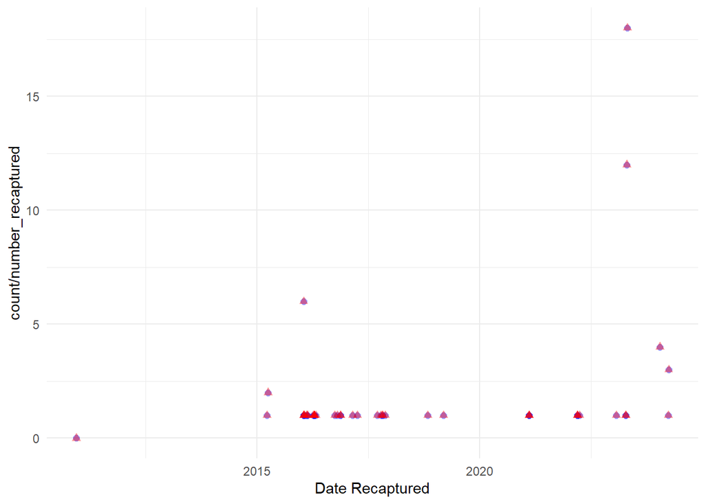

#### forkLength

*EDI `forkLength`*

- 56.5 % of values in the `forkLength` column are NA.

```
##    Min. 1st Qu.  Median    Mean 3rd Qu.    Max.    NA's
##   32.00   52.00   75.50   87.85  126.25  173.00      26
```

*DB `fork_length`*

- 56.5 % of values in the `fork_length` column are NA.

```
##    Min. 1st Qu.  Median    Mean 3rd Qu.    Max.    NA's
##   32.00   52.00   75.50   87.85  126.25  173.00      26
```

Random pick of data entry to compare between db and EDI

- test 1

```
## Rows: 1
## Columns: 17
## $ id               <int> 355521
## $ trap_location_id <int> 56
## $ catch_raw_id     <int> 55215
## $ date             <date> 2019-03-09
## $ count            <dbl> 1
## $ run_id           <int> 3
## $ lifestage_id     <int> 5
## $ adipose_clipped  <lgl> TRUE
## $ dead             <lgl> NA
## $ fork_length      <dbl> 58
## $ weight           <dbl> NA
## $ release_id       <chr> "303"
## $ updated_at       <dttm> 2025-07-08 23:06:37
## $ stream           <chr> "sacramento river"
## $ site             <chr> "tisdale"
## $ subsite          <chr> "rl"
## $ source           <chr> "DB"
```

```
## Rows: 1
## Columns: 24
## $ ProjectDescriptionID <dbl> 10
## $ catchRawID           <dbl> 55215
## $ trapVisitID          <dbl> 4769
## $ commonName           <chr> "Chinook salmon"
## $ releaseID            <dbl> 303
## $ atCaptureRun         <chr> "Fall"
## $ finalRun             <chr> NA
## $ fishOrigin           <chr> "Hatchery"
## $ lifeStage            <chr> "Parr"
## $ forkLength           <dbl> 58
## $ n                    <dbl> 1
## $ visitTime            <dttm> 2019-03-09 10:44:34
## $ visitTime2           <dttm> 2019-03-09 10:44:34
## $ visitType            <chr> "Continue trapping"
## $ siteName             <chr> "tisdale"
## $ subSiteName          <chr> "rl"
## $ markType             <chr> "Elastomer"
## $ markColor            <chr> "Orange"
## $ markPosition         <chr> "Nose"
## $ trap_start_date      <dttm> 2017-11-16 09:45:34
## $ trap_end_date        <dttm> 2019-03-09 10:44:34
## $ stream               <chr> "sacramento river"
## $ date                 <date> 2019-03-09
## $ source               <chr> "EDI"
```

- test 2

```
## Rows: 1
## Columns: 17
## $ id               <int> 355527
## $ trap_location_id <int> 55
## $ catch_raw_id     <int> 12772
## $ date             <date> 2016-01-21
## $ count            <dbl> 1
## $ run_id           <int> 3
## $ lifestage_id     <int> 5
## $ adipose_clipped  <lgl> FALSE
## $ dead             <lgl> NA
## $ fork_length      <dbl> 39
## $ weight           <dbl> NA
## $ release_id       <chr> "264"
## $ updated_at       <dttm> 2025-07-08 23:06:37
## $ stream           <chr> "sacramento river"
## $ site             <chr> "tisdale"
## $ subsite          <chr> "rr"
## $ source           <chr> "DB"
```

```
## Rows: 1
## Columns: 24
## $ ProjectDescriptionID <dbl> 10
## $ catchRawID           <dbl> 12772
## $ trapVisitID          <dbl> 1507
## $ commonName           <chr> "Chinook salmon"
## $ releaseID            <dbl> 264
## $ atCaptureRun         <chr> "Fall"
## $ finalRun             <chr> "Fall"
## $ fishOrigin           <chr> "Natural"
## $ lifeStage            <chr> "Parr"
## $ forkLength           <dbl> 39
## $ n                    <dbl> 1
## $ visitTime            <dttm> 2016-01-21 15:30:34
## $ visitTime2           <dttm> 2016-01-21 15:30:34
## $ visitType            <chr> "Continue trapping"
## $ siteName             <chr> "tisdale"
## $ subSiteName          <chr> "rr"
## $ markType             <chr> "Pigment / dye"
## $ markColor            <chr> "Brown"
## $ markPosition         <chr> "Whole body"
## $ trap_start_date      <dttm> 2016-01-21 15:30:34
## $ trap_end_date        <dttm> 2016-01-21 15:30:34
## $ stream               <chr> "sacramento river"
## $ date                 <date> 2016-01-21
## $ source               <chr> "EDI"
```

- test 3

```
## Rows: 1
## Columns: 17
## $ id               <int> 355537
## $ trap_location_id <int> 55
## $ catch_raw_id     <int> 41490
## $ date             <date> 2016-11-17
## $ count            <dbl> 1
## $ run_id           <int> 1
## $ lifestage_id     <int> 6
## $ adipose_clipped  <lgl> TRUE
## $ dead             <lgl> NA
## $ fork_length      <dbl> 109
## $ weight           <dbl> NA
## $ release_id       <chr> "274"
## $ updated_at       <dttm> 2025-07-08 23:06:37
## $ stream           <chr> "sacramento river"
## $ site             <chr> "tisdale"
## $ subsite          <chr> "rr"
## $ source           <chr> "DB"
```

```
## Rows: 1
## Columns: 24
## $ ProjectDescriptionID <dbl> 10
## $ catchRawID           <dbl> 41490
## $ trapVisitID          <dbl> 3024
## $ commonName           <chr> "Chinook salmon"
## $ releaseID            <dbl> 274
## $ atCaptureRun         <chr> "Late fall"
## $ finalRun             <chr> "Late fall"
## $ fishOrigin           <chr> "Hatchery"
## $ lifeStage            <chr> "Silvery parr"
## $ forkLength           <dbl> 109
## $ n                    <dbl> 1
## $ visitTime            <dttm> 2016-11-17 10:00:34
## $ visitTime2           <dttm> 2016-11-17 10:00:34
## $ visitType            <chr> "Continue trapping"
## $ siteName             <chr> "tisdale"
## $ subSiteName          <chr> "rr"
## $ markType             <chr> "Elastomer"
## $ markColor            <chr> "Orange"
## $ markPosition         <chr> "Nose"
## $ trap_start_date      <dttm> 2016-04-28 09:00:34
## $ trap_end_date        <dttm> 2016-11-17 10:00:34
## $ stream               <chr> "sacramento river"
## $ date                 <date> 2016-11-17
## $ source               <chr> "EDI"
```

- test 4

```
## Rows: 1
## Columns: 17
## $ id               <int> 355558
## $ trap_location_id <int> 55
## $ catch_raw_id     <int> 88918
## $ date             <date> 2024-03-29
## $ count            <dbl> 3
## $ run_id           <int> 2
## $ lifestage_id     <int> 6
## $ adipose_clipped  <lgl> FALSE
## $ dead             <lgl> NA
## $ fork_length      <dbl> NA
## $ weight           <dbl> NA
## $ release_id       <chr> "325"
## $ updated_at       <dttm> 2025-07-08 23:06:37
## $ stream           <chr> "sacramento river"
## $ site             <chr> "tisdale"
## $ subsite          <chr> "rr"
## $ source           <chr> "DB"
```

```
## Rows: 1
## Columns: 24
## $ ProjectDescriptionID <dbl> 10
## $ catchRawID           <dbl> 88918
## $ trapVisitID          <dbl> 7538
## $ commonName           <chr> "Chinook salmon"
## $ releaseID            <dbl> 325
## $ atCaptureRun         <chr> "Spring"
## $ finalRun             <chr> NA
## $ fishOrigin           <chr> "Natural"
## $ lifeStage            <chr> "Silvery parr"
## $ forkLength           <dbl> NA
## $ n                    <dbl> 3
## $ visitTime            <dttm> 2024-03-29 10:00:04
## $ visitTime2           <dttm> 2024-03-29 10:00:04
## $ visitType            <chr> "End trapping"
## $ siteName             <chr> "tisdale"
## $ subSiteName          <chr> "rr"
## $ markType             <chr> "Elastomer"
## $ markColor            <chr> "Red"
## $ markPosition         <chr> "Nose"
## $ trap_start_date      <dttm> 2024-03-27 10:00:13
## $ trap_end_date        <dttm> 2024-03-29 10:00:04
## $ stream               <chr> "sacramento river"
## $ date                 <date> 2024-03-29
## $ source               <chr> "EDI"
```